# Análisis Empresa Minorista Online

Urko

2023-04-29

### Librerías y Archivos.

A continuación se cargan las librerías que se utilizarán a los largo del proceso de análisis de datos:

```r
library(tidyverse)
library("janitor")
library(dplyr)
library(scales)
library(lubridate)
library(splines)
library(ggthemes)
library(extrafont)
```

Se trabajará con dos archivos de datos que contienen:

- Los datos de la contabilidad mensual entre los años 2017 y 2019:

```r
contabilidad_mensual <- read.csv("C:/Users/regue/Desktop/GOOGLE ANALYTICS/Final project/Online_Retailer_analysis/Data/contabilidad.csv")
```

- Los datos de las ventas de productos online entre los años 2017 y 2019:

```r
venta_productos <- read.csv("C:/Users/regue/Desktop/GOOGLE ANALYTICS/Final project/Online_Retailer_analysis/Data/ventas.csv")
```

### Venta de productos online.

Se comienza visualizando el tipo de datos que contiene el archivo “venta_productos”:

```r
head(venta_productos)
```

```
##      Product.Type Net.Quantity Gross.Sales Discounts Returns Total.Net.Sales
## 1 Art & Sculpture           34     14935.0   -594.00   -1609        12732.00
## 2          Basket           13      3744.0   -316.80       0         3427.20
## 3          Basket           12      3825.0   -201.60    -288         3335.40
## 4          Basket           17      3035.0    -63.25       0         2971.75
## 5 Art & Sculpture           47      2696.8    -44.16       0         2652.64
## 6          Basket           17      2695.0    -52.50    -110         2532.50
```

```r
glimpse(venta_productos)
```

```
## Rows: 1,775
## Columns: 6
## $ Product.Type    <chr> "Art & Sculpture", "Basket", "Basket", "Basket", "Art …
## $ Net.Quantity    <int> 34, 13, 12, 17, 47, 17, 20, 90, 10, 11, 30, 19, 15, 2,…
## $ Gross.Sales     <dbl> 14935.0, 3744.0, 3825.0, 3035.0, 2696.8, 2695.0, 2310.…
## $ Discounts       <dbl> -594.00, -316.80, -201.60, -63.25, -44.16, -52.50, -66…
## $ Returns         <dbl> -1609, 0, -288, 0, 0, -110, -110, 0, 0, 0, 0, 0, 0, 0,…
## $ Total.Net.Sales <dbl> 12732.00, 3427.20, 3335.40, 2971.75, 2652.64, 2532.50,…
```

```r
str(venta_productos)
```

```
## 'data.frame':    1775 obs. of  6 variables:
##  $ Product.Type   : chr  "Art & Sculpture" "Basket" "Basket" "Basket" ...
##  $ Net.Quantity   : int  34 13 12 17 47 17 20 90 10 11 ...
##  $ Gross.Sales    : num  14935 3744 3825 3035 2697 ...
##  $ Discounts      : num  -594 -316.8 -201.6 -63.2 -44.2 ...
##  $ Returns        : num  -1609 0 -288 0 0 ...
##  $ Total.Net.Sales: num  12732 3427 3335 2972 2653 ...
```

```r
View(venta_productos)
```

## Limpieza de datos.

Se comprueba si hay algún valor NA en el dataframe:

```r
any(is.na(venta_productos))
```

```
## [1] FALSE
```

Se encuentra una categoría vacía y valores negativos en la fila 1767, procediendose a eliminar los datos incongruentes:

```r
venta_productos_clean <- venta_productos %>%
  filter(Product.Type != "", Total.Net.Sales >= 0) %>%
  arrange(desc(Net.Quantity))
```

## Análisis de datos.

Se resume el número total de productos vendidos por categoría:

```r
resumen_ventas <- venta_productos_clean %>%
  group_by(Product.Type) %>%
  summarize(total_vendidos = sum(Net.Quantity),
            total_descuentos = sum(Discounts),
            total_ganancias = sum(Total.Net.Sales)) %>%
  mutate(porcentaje = total_ganancias * 100 / sum(total_ganancias)) %>%
  arrange(desc(total_ganancias))
```

Se eligen las categorías más relevantes aquellas cuyos ingresos sean mayores al 4%, el resto se categorizan como “Otras”:

```r
producto_relevante <- resumen_ventas %>%
  select(Product.Type,total_vendidos, total_ganancias, porcentaje) %>%
  filter(porcentaje > 4)

producto_menos_relevante <- resumen_ventas %>%
  select(Product.Type, total_vendidos, total_ganancias, porcentaje) %>%
  filter(porcentaje < 4)

producto_menos_relevante_resumen <- data.frame(Product.Type = "Others",
                                               total_vendidos = sum(producto_menos_relevante$total_vendidos),
                                               total_ganancias = sum(producto_menos_relevante$total_ganancias),
                                               porcentaje = sum(producto_menos_relevante$porcentaje))

# JUNTO DATOS:

resumen_ventas_filtrada <- rbind(producto_relevante, producto_menos_relevante_resumen)
```

Se presenta el dataframe con el que se realizarán las viz’s:

```r
str(resumen_ventas_filtrada)
```

```
## tibble [7 × 4] (S3: tbl_df/tbl/data.frame)
##  $ Product.Type   : chr [1:7] "Basket" "Art & Sculpture" "Jewelry" "Home Decor" ...
##  $ total_vendidos : int [1:7] 1461 1427 991 404 810 575 915
##  $ total_ganancias: num [1:7] 134791 84481 29573 25700 15443 ...
##  $ porcentaje     : num [1:7] 40.45 25.36 8.88 7.71 4.63 ...
```

```r
View(resumen_ventas_filtrada)
```

## Visualización de datos.

Se presentan a continuación los beneficios netos por categoría:

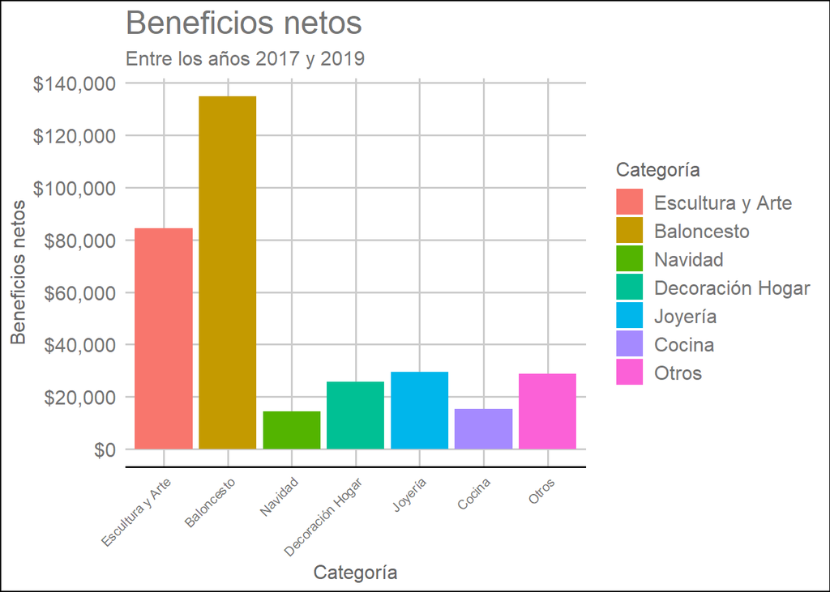

```r
ggplot(resumen_ventas_filtrada) +
  geom_bar(mapping = aes(x = Product.Type, y = total_ganancias, fill = Product.Type), stat = "identity") +
  scale_y_continuous(labels = scales::dollar,
                     breaks = seq(0, 250000, by = 20000)) +
  scale_x_discrete(labels = c("Escultura y Arte",
                              "Baloncesto",
                              "Navidad",
                              "Decoración Hogar",
                              "Joyería",
                              "Cocina",
                              "Otros")) +
  scale_fill_discrete(labels = c("Escultura y Arte",
                                 "Baloncesto",
                                 "Navidad",
                                 "Decoración Hogar",
                                 "Joyería",
                                 "Cocina",
                                 "Otros")) +
  labs(title = "Beneficios netos",
       subtitle = "Entre los años 2017 y 2019",
       x = "Categoría",
       y = "Beneficios netos",
       fill = "Categoría") +
  theme_gdocs() +
  theme(axis.text.x = element_text(angle = 45, vjust = 1, hjust=1, size = 8))
```

Mediante un pie chart:

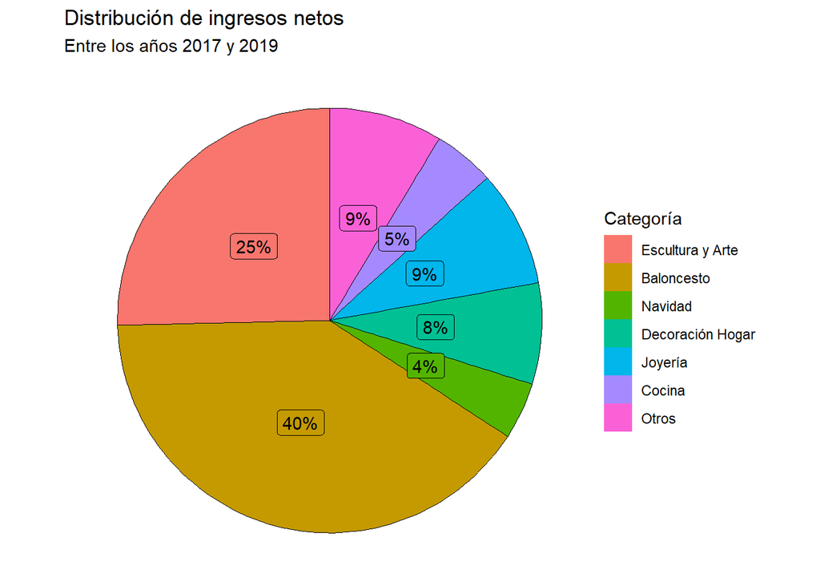

```r
ggplot(resumen_ventas_filtrada,
       aes(x = "", y = total_ganancias , fill = Product.Type)) +
  theme_gdocs() +
  geom_col(width = 1, color = "black", size = 0.25) +
  coord_polar("y", start=0) +
  theme_void() +
  geom_label(aes(label = paste0(round(porcentaje), "%")),
             position = position_stack(vjust = 0.5)) +
  labs(title = "Distribución de ingresos netos",
       subtitle = "Entre los años 2017 y 2019",
       fill = "Tipo de producto") +
  scale_fill_discrete(labels = c("Escultura y Arte",
                                 "Baloncesto",
                                 "Navidad",
                                 "Decoración Hogar",
                                 "Joyería",
                                 "Cocina",
                                 "Otros")) +
  guides(fill = guide_legend(title = "Categoría",
                             override.aes = aes(label = "")))
```

Se visualiza a continuación un gráfico de barras para identificar la categoría de procutos más vendidos:

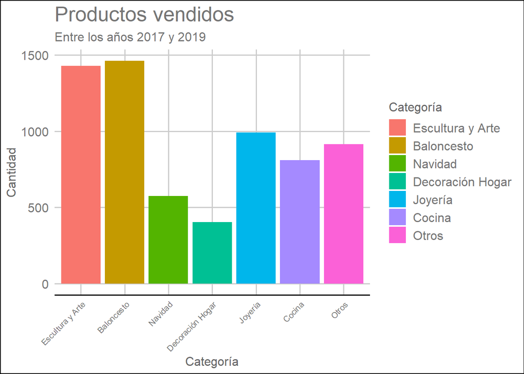

```r
ggplot(resumen_ventas_filtrada) +
  geom_bar(mapping = aes(x=Product.Type, y = total_vendidos, fill = Product.Type),
           stat = "identity") +
  scale_y_continuous(breaks = seq(0, 2500, by = 500)) +
  scale_x_discrete(labels = c("Escultura y Arte",
                              "Baloncesto",
                              "Navidad",
                              "Decoración Hogar",
                              "Joyería",
                              "Cocina",
                              "Otros")) +
  scale_fill_discrete(labels = c("Escultura y Arte",
                                 "Baloncesto",
                                 "Navidad",
                                 "Decoración Hogar",
                                 "Joyería",
                                 "Cocina",
                                 "Otros")) +
  labs(title = "Productos vendidos",
       subtitle = "Entre los años 2017 y 2019",
       x = "Categoría",
       y = "Cantidad",
       fill = "Categoría") +
  theme_gdocs() +
  theme(axis.text.x = element_text(angle = 45, vjust = 1, hjust=1, size = 8))
```

### Contabilidad mensual.

Se comienza visualizando el tipo de datos que contiene el archivo “contabilidad_mensual”:

```r
head(contabilidad_mensual)
```

```
##      Month Year Total.Orders Gross.Sales Discounts  Returns Net.Sales Shipping
## 1  January 2017           73      8861.5   -129.40  -448.45   8283.65  1088.30
## 2 February 2017           56      6908.5   -104.70  -416.20   6387.60   892.45
## 3    March 2017           60      5778.5   -172.20 -1017.20   4589.10   707.43
## 4    April 2017           70      8814.0   -281.40     0.00   8532.60  1068.30
## 5      May 2017           54      6677.0   -185.75  -253.80   6237.45   866.46
## 6     June 2017           68      9621.5   -234.45   -17.50   9369.55  1204.32
##   Total.Sales
## 1     9371.95
## 2     7280.05
## 3     5296.53
## 4     9600.90
## 5     7103.91
## 6    10573.87
```

```r
glimpse(contabilidad_mensual)
```

```
## Rows: 36
## Columns: 9
## $ Month        <chr> "January", "February", "March", "April", "May", "June", "…
## $ Year         <int> 2017, 2017, 2017, 2017, 2017, 2017, 2017, 2017, 2017, 201…
## $ Total.Orders <int> 73, 56, 60, 70, 54, 68, 66, 55, 68, 59, 91, 116, 83, 69, …
## $ Gross.Sales  <dbl> 8861.50, 6908.50, 5778.50, 8814.00, 6677.00, 9621.50, 648…
## $ Discounts    <dbl> -129.40, -104.70, -172.20, -281.40, -185.75, -234.45, -51…
## $ Returns      <dbl> -448.45, -416.20, -1017.20, 0.00, -253.80, -17.50, -469.2…
## $ Net.Sales    <dbl> 8283.65, 6387.60, 4589.10, 8532.60, 6237.45, 9369.55, 595…
## $ Shipping     <dbl> 1088.30, 892.45, 707.43, 1068.30, 866.46, 1204.32, 807.36…
## $ Total.Sales  <dbl> 9371.95, 7280.05, 5296.53, 9600.90, 7103.91, 10573.87, 67…
```

```r
str(contabilidad_mensual)
```

```
## 'data.frame':    36 obs. of  9 variables:
##  $ Month       : chr  "January" "February" "March" "April" ...
##  $ Year        : int  2017 2017 2017 2017 2017 2017 2017 2017 2017 2017 ...
##  $ Total.Orders: int  73 56 60 70 54 68 66 55 68 59 ...
##  $ Gross.Sales : num  8862 6908 5778 8814 6677 ...
##  $ Discounts   : num  -129 -105 -172 -281 -186 ...
##  $ Returns     : num  -448 -416 -1017 0 -254 ...
##  $ Net.Sales   : num  8284 6388 4589 8533 6237 ...
##  $ Shipping    : num  1088 892 707 1068 866 ...
##  $ Total.Sales : num  9372 7280 5297 9601 7104 ...
```

```r
View(contabilidad_mensual)
```

## Limpieza de datos.

Se comprueba si hay algún valor NA en el dataframe:

```r
any(is.na(contabilidad_mensual))
```

```
## [1] FALSE
```

Se juntan las columnas “Year” y “Month” en una llamada “Date”. A continuación se cambia la columna “Date” a formato fecha:

```r
contabilidad_mensual <- contabilidad_mensual %>%
  mutate(Date = ymd(paste0(Year, Month, "-01")))
```

Se cambia el nombre de las columnas “Year” y “Month” por “Año” y “Mes”:

```r
contabilidad_mensual_clean <- contabilidad_mensual %>%
  select(Date,
         Total.Orders,
         Net.Sales,
         Total.Sales,
         Year,
         Month) %>%
  rename(Año = Year, Mes = Month)
```

## Análisis de datos.

Se resumen las ganancias netas al mes agrupado por año:

```r
resumen_ganancias <- contabilidad_mensual_clean %>%
  group_by(Año) %>%
  summarise(Ganancias_Netas = sum(Net.Sales))
```

A su vez, se resume el número total de pedidos/mes agrupado por año:

```r
resumen_pedidos <- contabilidad_mensual_clean %>%
  group_by(Año) %>%
  summarise(total_pedidos_mes = sum(Total.Orders))
```

Se convierte la columna año a factor:

```r
contabilidad_mensual_clean$Año <- format(contabilidad_mensual_clean$Año)

resumen_ganancias$Año <- factor(resumen_ganancias$Año)
```

Se calcula la tasa de crecimiento anual para los años 2018 y 2019:

```r
tasa_anual <- data.frame(
  Año = resumen_ganancias$Año[-1],
  Tasa_crecimiento = ((resumen_ganancias$Ganancias_Netas[-1] / resumen_ganancias$Ganancias_Netas[-length(resumen_ganancias$Ganancias_Netas)]) - 1) * 100
)
```

Se calcula el número de pedidos totales trimestralmente:

```r
pedidos_trimestre <- contabilidad_mensual_clean %>%
  mutate(Trimestre = quarter(Date)) %>%
  group_by(Year = year(Date), Trimestre) %>%
  summarise(Total.Orders = sum(Total.Orders))
```

Ahora se calcula el incremento en el número de pedidos trimestral para cada año:

```r
pedidos_trimestre <- pedidos_trimestre %>%
  mutate(Incremento = (Total.Orders / lag(Total.Orders, default = first(Total.Orders)) - 1)*100)
```

Se presentan los dataframes con los que se trabaja:

```r
str(contabilidad_mensual_clean)
```

```
## 'data.frame':    36 obs. of  6 variables:
##  $ Date        : Date, format: "2017-01-01" "2017-02-01" ...
##  $ Total.Orders: int  73 56 60 70 54 68 66 55 68 59 ...
##  $ Net.Sales   : num  8284 6388 4589 8533 6237 ...
##  $ Total.Sales : num  9372 7280 5297 9601 7104 ...
##  $ Año         : chr  "2017" "2017" "2017" "2017" ...
##  $ Mes         : chr  "January" "February" "March" "April" ...
```

```r
View(contabilidad_mensual_clean)

str(resumen_ganancias)
```

```
## tibble [3 × 2] (S3: tbl_df/tbl/data.frame)
##  $ Año            : Factor w/ 3 levels "2017","2018",..: 1 2 3
##  $ Ganancias_Netas: num [1:3] 91521 104788 129796
```

```r
View(resumen_ganancias)

head(tasa_anual)
```

```
##    Año Tasa_crecimiento
## 1 2018         14.49695
## 2 2019         23.86550
```

```r
View(tasa_anual)

head(pedidos_trimestre)
```

```
## # A tibble: 6 × 4
## # Groups:   Year [2]
##    Year Trimestre Total.Orders Incremento
##   <dbl>     <int>        <int>      <dbl>
## 1  2017         1          189       0
## 2  2017         2          192       1.59
## 3  2017         3          189      -1.56
## 4  2017         4          266      40.7
## 5  2018         1          216       0
## 6  2018         2          287      32.9
```

```r
View(pedidos_trimestre)
```

## Visualización de datos.

Se define el vector de colores que utilizaremos en las visualizaciones:

```r
colores <- c("#72D9FF", "#3FA0FF", "#290AD8")
```

Se visualiza a continuación cual ha sido la tendencia de ganancias en los años 2017, 2018 y 2019:

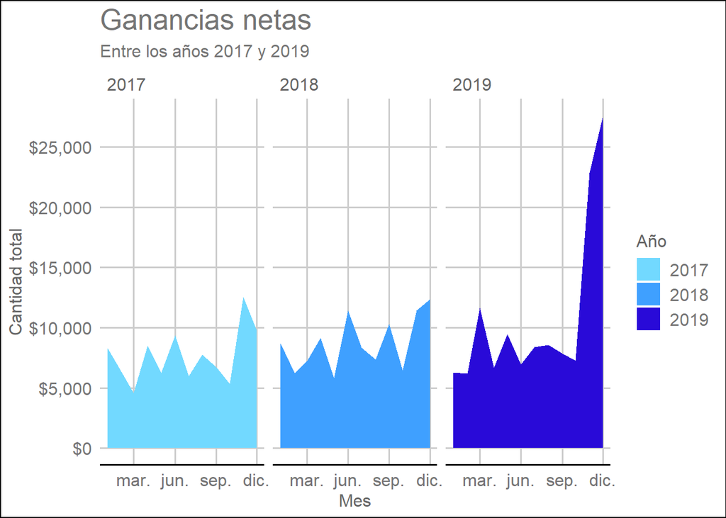

```r
ggplot(contabilidad_mensual_clean) +
  geom_area(mapping = aes(x = Date, y = Net.Sales, fill = Año),
            stat = "identity") +
  facet_wrap(~Año,
             scales = "free_x") +
  theme(axis.text.x = element_text(angle = 45, vjust = 0.5, size = 6)) +
  scale_x_date(date_breaks = "3 month",
               date_labels = "%b") +
  scale_y_continuous(labels = scales::dollar,
                     breaks = seq(0, 45000, by = 5000)) +
  scale_fill_manual(values = colores) +
  labs(title = "Ganancias netas",
       subtitle = "Entre los años 2017 y 2019",
       x = "Mes",
       y = "Cantidad total") +
  theme_gdocs()
```

Se ajusta a una recta:

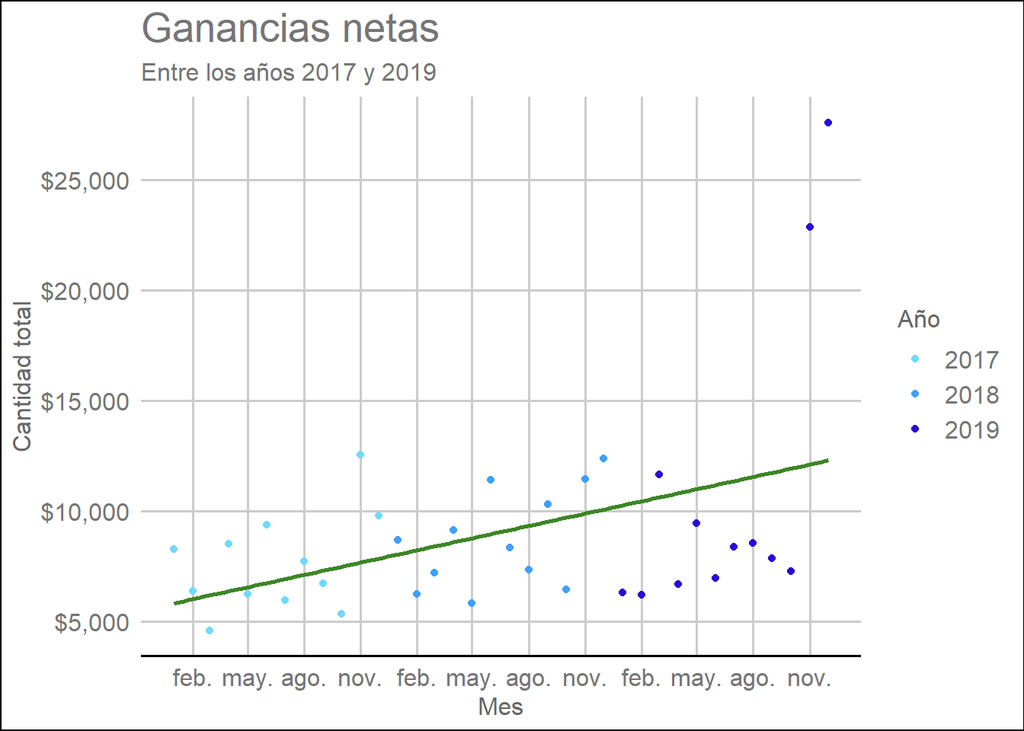

```r
ggplot(contabilidad_mensual_clean) +
  geom_point(mapping = aes(x = Date, y = Net.Sales, color = Año),
             stat = "identity") +
  geom_smooth(mapping = aes(x = Date, y = Net.Sales),
              method = "lm",
              se = FALSE,
              color = "#3C8625") +
  theme(axis.text.x = element_text(angle = 45, vjust = 0.5, size = 6)) +
  scale_x_date(date_breaks = "3 month",
               date_labels = "%b") +
  scale_y_continuous(labels = scales::dollar,
                     breaks = seq(0, 45000, by = 5000)) +
  scale_color_manual(values = colores) +
  labs(title = "Ganancias netas",
       subtitle = "Entre los años 2017 y 2019",
       x = "Mes",
       y = "Cantidad total") +
  theme_gdocs()
```

Se visualizan ahora el número de pedidos/mes realizados los años 2017, 2018 y 2019:

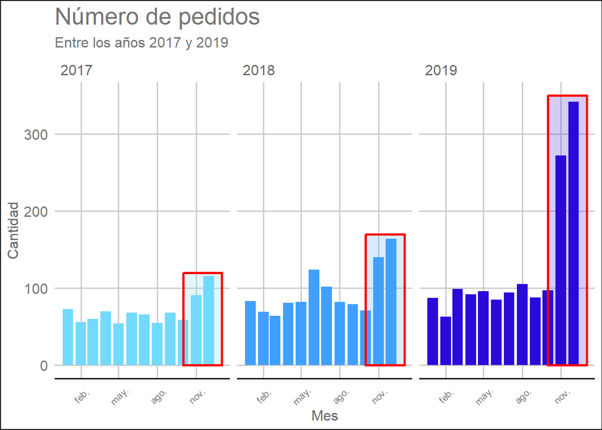

```r
rect_data <- data.frame(Año = c("2017", "2018", "2019"),
                        rect_xmin = as.Date(c("2017-10-01",
                                              "2018-10-01",
                                              "2019-10-01")),
                        rect_xmax = as.Date(c("2018-01-01",
                                              "2019-01-01",
                                              "2020-01-01")),
                        rect_ymin = c(0, 0, 0),
                        rect_ymax = c(120, 170, 350))


ggplot(contabilidad_mensual_clean) +
  geom_bar(mapping = aes(x = Date, y = Total.Orders, fill = Año),
           stat = "identity",
           show.legend = FALSE) +
  facet_wrap(~Año, scales = "free_x") +
  scale_x_date(date_breaks = "3 month", date_labels = "%b") +
  scale_y_continuous(breaks = seq(0, 500, by = 100)) +
  scale_fill_manual(values = colores) +
  labs(title = "Número de pedidos",
       subtitle = "Entre los años 2017 y 2019",
       x = "Mes",
       y = "Cantidad") +
  geom_rect(data = rect_data,
            mapping = aes(xmin = rect_xmin,
                          xmax = rect_xmax,
                          ymin = rect_ymin,
                          ymax = rect_ymax,
                          fill = Año),
            alpha = 0.2,
            color = "red",
            inherit.aes = FALSE,
            size = 1,
            show.legend = FALSE) +
  theme_gdocs() +
  theme(axis.text.x = element_text(angle = 45, vjust = 0.5, size = 8))
```

Y su tendencia:

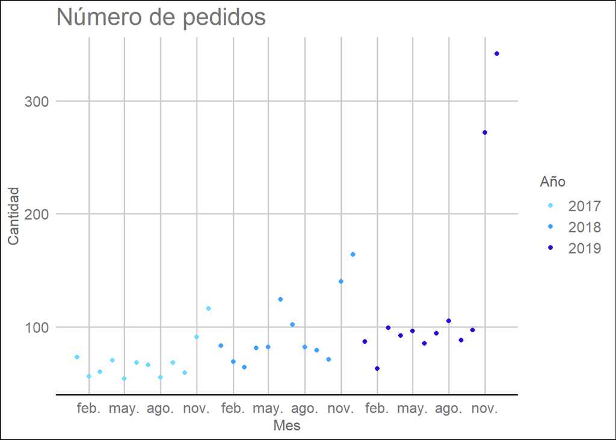

```r
ggplot(contabilidad_mensual_clean) +
  geom_point(mapping = aes(x = Date, y = Total.Orders, color = Año),
             stat = "identity") +
  theme(axis.text.x = element_text(angle = 45, vjust = 0.5, size = 6)) +
  scale_x_date(date_breaks = "3 month",
               date_labels = "%b") +
  scale_y_continuous(breaks = seq(0, 500, by = 100)) +
  scale_color_manual(values = colores) +
  labs(title = "Número de pedidos",
       x = "Mes",
       y = "Cantidad") +
  theme_gdocs()
```

Por último se visualizan las ganancias netas para cada año:

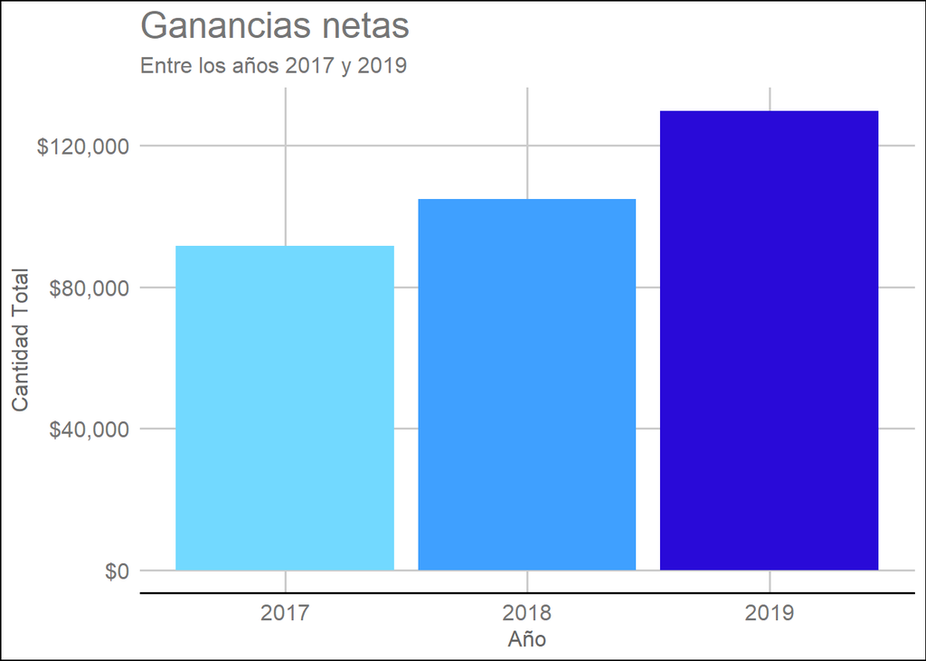

```r
ggplot(resumen_ganancias) +
  geom_bar(mapping = aes(x = Año, y = Ganancias_Netas, fill = Año),
           stat = "identity",
           show.legend = FALSE) +
  theme(axis.text.x = element_text(angle = 0, vjust = 0.5, size = 10)) +
  scale_y_continuous(labels = scales::dollar,
                     breaks = seq(0, 300000, by = 40000)) +
  scale_fill_manual(values = colores) +
  labs(title = "Ganancias netas",
       subtitle = "Entre los años 2017 y 2019",
       x = "Año",
       y = "Cantidad Total") +
  theme_gdocs()
```